# ESM232 A2 function application

Margaret Brickner, Nathalie Eegholm, Ruoyu Wang

4/7/2021

### 1. The function

```r
#This is our function which models annual yield anomalies based research conducted by Lobell et al., 2006. More details, including variables and parameters, are in the R script.
source("R/almond_yield_anomaly.R")
```

### 2. Data wrangling

**This subsetting process requires the following column formatting:**

```r
# Read in climate data.
clim <- read.table("clim.txt")

# We need to subset the precipitation data for the January precipitation parameter.
# First, filter for January data (month == 1).
precip <- clim %>%
  filter(month == 1)

# Then, group the precipitation data by year and then sum to create annual January rainfall totals.
jan_precip_sum <- precip %>%
  group_by(year) %>%
  summarize(
    jan_precip_sum = sum(precip)
  )

# Next we need to subset the temperature data for the Feburary temperature parameter.
# First, filter for February.
temp <- clim %>%
  filter(month == 2)

# Then, group by year and find the average value each year.
feb_temp_min <- temp %>%
  group_by(year) %>%
  summarize(
    feb_tmin = mean(tmin_c)
  )
```

### 3. Function application

```r
# Data subsetting is complete.
# Now time to generate our outputs (annual yield anomaly in ton/acre).

# Generate vector of years
yset <- jan_precip_sum$year

# Generate empty holding list to store yield anomalies for each year using yset vector generated.
yieldanoms<- NaN*(yset)

# Loop through years and store yield anomaly outputs in yieldanoms vector.
for(j in 1:length(yieldanoms)){
  yieldanoms[j]<-almond_yield_anomaly(feb_temp_min[j,2],
                         jan_precip_sum[j,2])
                         }

#Next convert the results to a df to use ggplot. First list to a vector.
yieldanoms_vector <- unlist(yieldanoms)

#Next to a dataframe.
yieldanoms_df<- data.frame(yset, yieldanoms_vector) %>%
  rename(year = yset,
         yield_anomaly = yieldanoms_vector) %>%
  merge(feb_temp_min, by = "year") %>%
  merge(jan_precip_sum, by = "year") %>%
  rename(jan_precip = jan_precip_sum)
```

### 4. Result plots

For simplicity, we will not include the codes related to plot and table generation in the final report. All data used in Section 4 came from `yieldanoms_df`. Feel free to access to our full Rmd codes [here](https://github.com/Ruoyu-Wang108/ESM232-A2/blob/main/MB-NE-RW-ESM232-A2.Rmd).

#### 4.1 The historic yield anomalies

First we wanted to plot the historic yield anomalies as output by the Lobell et al. function.

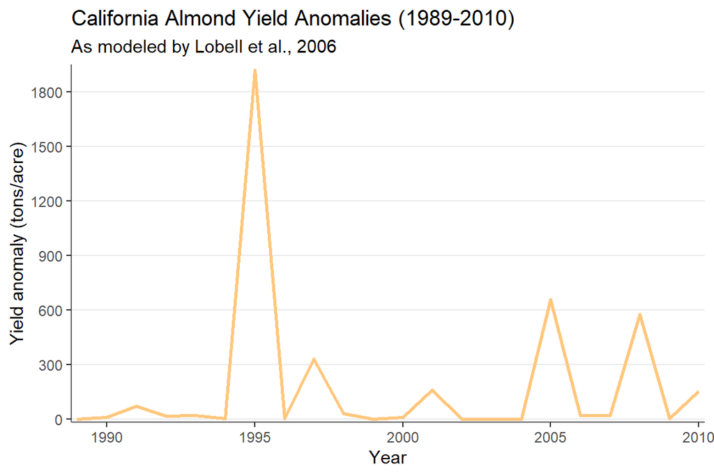

*Figure 1.* *California almond yield anomalies from 1989-2010 modeled using the statistical model developed by Lobell et al., 2006.*